# Simple linear regression

## Simple linear regression

- Simple linear regression refers to fitting a straight line $y = \beta_0 + \beta_1 x$ to a set of bivariate data.

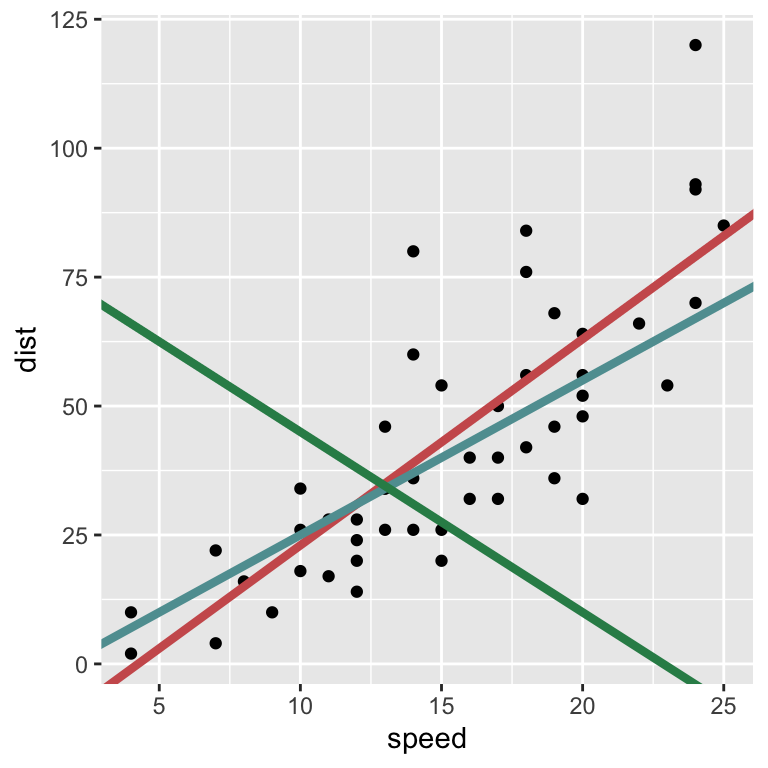

```r
ggplot(cars, aes(speed, dist)) +
  geom_point() +
  geom_abline(intercept = -17,
              slope = 4, size = 1.5,
              color = "indianred") +
  geom_abline(intercept = -5,
              slope = 3, size = 1.5,
              color = "cadetblue")  +
  geom_abline(intercept = 80,
              slope = -3.5, size = 1.5,
              color = "seagreen")
```

## Residuals

- A strategy to find the best line of fit is generally based on residuals.
- In simple linear regression, the **residuals** are the vertical distance of the observations from the fitted line.

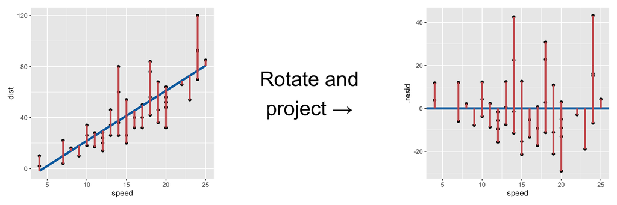

## Least squares

$$y = \beta_0 + \beta_1 x$$

- **Method of least squares** to estimate the parameters, $\beta_0$ (intercept) and $\beta_1$ (slope).
- Method of least squares estimate parameters such that it minimizes the residual sum of the squares (RSS).
- **Residuals** = observed $-$ fitted value.
- **Fitted value** = the predicted response $(y)$ value from the fitted model using predictors $(x)$ from the data
- Unless stated otherwise, simple linear regression uses the **method of least squares** to estimate the model parameters.
- Method of least squares estimates the model parameters by finding parameters that minimise the sum of the squares of the residual.
- More formally, residuals are the difference of observed value from the fitted value.
- Fitted values are the predicted response value under the fitted model for the predictors in the data.

## Sum of the squares of the residuals

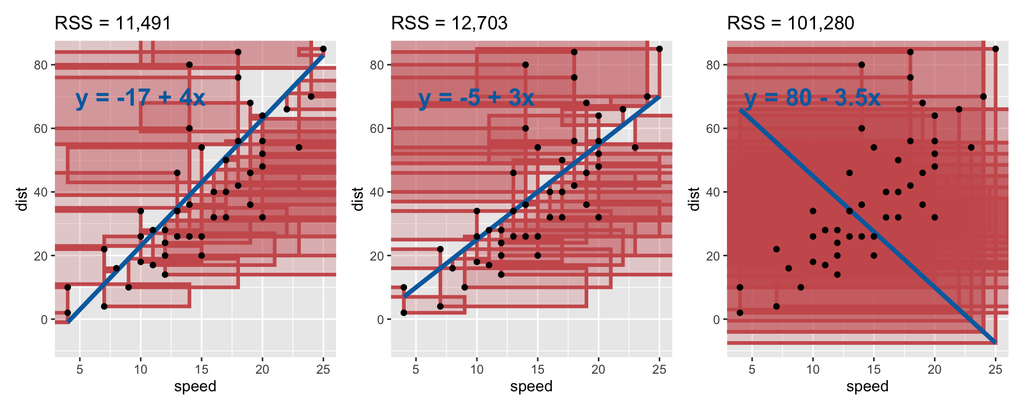

- The sum of the red squares are the residual sum of squares (RSS) – the actual RSS can be seen on top of the plot
- It doesn’t look like squares because the scale on the x- and y-axis differ
- There is a closed-form solution to finding parameters that minimise the residual sum of the squares.
- You can use calculus to find this or consult any standard first year statsitics text book.

## Linear regression in R

- In R, you can fit a linear regression using the method of least squares using the `lm()` function.
- The input for `lm` is a **two-sided formula** that symbolically represents the linear model.
- For example, `y ~ 1 + x` corresponds to a linear model

$$\color{#006dae}{y_i} = \beta_0 \cdot \color{#006dae}{1} + \beta_1 \cdot \color{#006dae}{x_i} + e_i, \qquad\text{for } i = 1, ..., n.$$

- The intercept term `1` is included by default.
- So `lm(y ~ 1 + x)` is the same as `lm(y ~ x)` .

## Fitting the linear regression with R

- To fit a linear regression, it’s best to parse the `data.frame` into the `data` argument.
- The variables in the formula refers to the variables in the input data.

```r
fit <- lm(dist ~  speed, data = cars)
```

- To get the model parameter estimates, referred to also as **coefficients**, you can use `coef` function on the model object:

```r
coef(fit)
```

```
## (Intercept)       speed
##  -17.579095    3.932409
```

## Model summaries

```r
summary(fit)
```

```
##
## Call:
## lm(formula = dist ~ speed, data = cars)
##
## Residuals:
##     Min      1Q  Median      3Q     Max
## -29.069  -9.525  -2.272   9.215  43.201
##
## Coefficients:
##             Estimate Std. Error t value Pr(>|t|)
## (Intercept) -17.5791     6.7584  -2.601   0.0123 *
## speed         3.9324     0.4155   9.464 1.49e-12 ***
## ---
## Signif. codes:  0 '***' 0.001 '**' 0.01 '*' 0.05 '.' 0.1 ' ' 1
##
## Residual standard error: 15.38 on 48 degrees of freedom
## Multiple R-squared:  0.6511, Adjusted R-squared:  0.6438
## F-statistic: 89.57 on 1 and 48 DF,  p-value: 1.49e-12
```

## Exracting model summary data

- You can see useful information from `summary(fit)` but it is not easy to extract it as a tidy data.
- The package `broom` has handy functions to get the summary values out in a tidy format:

```r
broom::tidy(fit)
```

```
## # A tibble: 2 × 5
##   term        estimate std.error statistic  p.value
##   <chr>          <dbl>     <dbl>     <dbl>    <dbl>
## 1 (Intercept)   -17.6      6.76      -2.60 1.23e- 2
## 2 speed           3.93     0.416      9.46 1.49e-12
```

```r
broom::glance(fit)
```

```
## # A tibble: 1 × 12
##   r.squared adj.r.squared sigma statistic  p.value    df logLik   AIC   BIC
##       <dbl>         <dbl> <dbl>     <dbl>    <dbl> <dbl>  <dbl> <dbl> <dbl>
## 1     0.651         0.644  15.4      89.6 1.49e-12     1  -207.  419.  425.
## # … with 3 more variables: deviance <dbl>, df.residual <int>, nobs <int>
```

## Augment data with model information

- You can also easily augment the data with model information, e.g. fitted values and residuals.

```r
broom::augment(fit)
```

```
## # A tibble: 50 × 8
##     dist speed .fitted .resid   .hat .sigma  .cooksd .std.resid
##    <dbl> <dbl>   <dbl>  <dbl>  <dbl>  <dbl>    <dbl>      <dbl>
##  1     2     4   -1.85   3.85 0.115    15.5 0.00459       0.266
##  2    10     4   -1.85  11.8  0.115    15.4 0.0435        0.819
##  3     4     7    9.95  -5.95 0.0715   15.5 0.00620      -0.401
##  4    22     7    9.95  12.1  0.0715   15.4 0.0255        0.813
##  5    16     8   13.9    2.12 0.0600   15.5 0.000645      0.142
##  6    10     9   17.8   -7.81 0.0499   15.5 0.00713      -0.521
##  7    18    10   21.7   -3.74 0.0413   15.5 0.00133      -0.249
##  8    26    10   21.7    4.26 0.0413   15.5 0.00172       0.283
##  9    34    10   21.7   12.3  0.0413   15.4 0.0143        0.814
## 10    17    11   25.7   -8.68 0.0341   15.5 0.00582      -0.574
## # … with 40 more rows
```

## Predictions from the fitted model

$$\widehat{\texttt{dist}} = -17.58 + 3.93\cdot \texttt{speed}$$

- The `predict` function can return predicted response values from a fitted model:

```r
predict(fit, data.frame(speed = c(5, 10)))
```

```
##         1         2
##  2.082949 21.744993
```

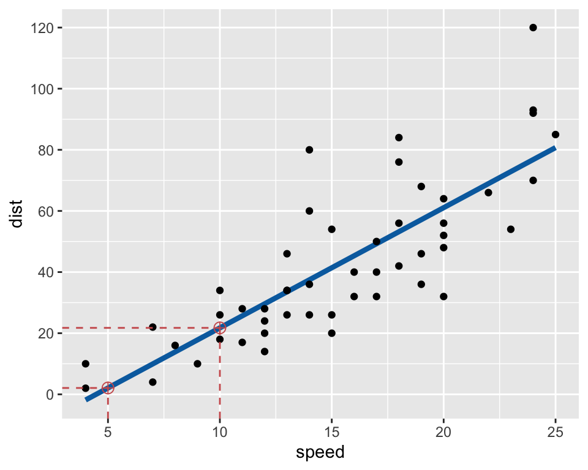